# Regressions

Johanna Mehler

2024-05-03

# 1 Data preparation

## 1.1 Libraries and read in data

```r
library(tidyverse)
library(readr)
library(here)
library(table1)
```

```r
library(ggplot2)
library(lmtest)
library(stargazer)
# data <- read_csv(here("data/data_combined.csv"))

data <- read_csv(here("data", "data_combined.csv"),
                 col_types = cols(
                   academic_status = col_factor(levels = c("non-academic", "academic")),
                   educ_cat = col_factor(levels = c("Low", "Intermediate", "High")),
                   gender = col_factor(levels = c("Male", "Female", "Other")),
                   monority_cat = col_factor(levels = c("Non-minority", "Minority")),
                   age_cat = col_factor(levels = c("18-29", "30-49", "50-69", "70+")),
                   polinterest_cat_3 = col_factor(levels = c("Low", "Intermediate", "High")),
                   empathy_pc_cat = col_factor(levels = c("Less empathetic", "More empathetic")),
                   exp_hate_speech_cat = col_factor(levels = c("Less experience", "More experience")),
                   exp_hostile_engagement_cat = col_factor(levels = c("Less experience", "More experience")),
                   cluster = col_factor(levels = c("Intent-based", "Harms-based", "Harms-based narrow", "Denying/Nonsense")),
                   leftright_cat = col_factor(levels = c("liberal/left", "moderate/center", "conservative/right")),
                   commitment_cat = col_factor(levels = c("Below average", "Above Average"))
                 ))
# filter out NA's in academic status and extreme outliers
data <- data %>% filter(!is.na(educ_cat), !is.na(academic_status), text_length < 1000, readability_score < 40)

# check data types and scales
data %>% summary()
```

```
##   ResponseId          leftright      leftright_pred_error
##  Length:1063        Min.   : 1.000   Min.   :0.00336
##  Class :character   1st Qu.: 5.000   1st Qu.:0.81825
##  Mode  :character   Median : 6.000   Median :1.65704
##                     Mean   : 6.178   Mean   :2.14149
##                     3rd Qu.: 8.000   3rd Qu.:3.15173
##                     Max.   :11.000   Max.   :9.92750
##                     NA's   :13       NA's   :223
##             leftright_cat               cluster    readability_score
##  liberal/left      :262   Intent-based      :308   Min.   :-7.940
##  moderate/center   :472   Harms-based       :374   1st Qu.: 8.129
##  conservative/right:316   Harms-based narrow:199   Median :11.542
##  NA's              : 13   Denying/Nonsense  :182   Mean   :11.565
##                                                    3rd Qu.:14.656
##                                                    Max.   :32.253
##
##  hate_definition     text_length    text_length_log2     academic_status
##  Length:1063        Min.   :  1.0   Min.   :0.000    non-academic:458
##  Class :character   1st Qu.: 58.0   1st Qu.:5.858    academic    :605
##  Mode  :character   Median : 98.0   Median :6.615
##                     Mean   :131.5   Mean   :6.538
##                     3rd Qu.:161.0   3rd Qu.:7.331
##                     Max.   :894.0   Max.   :9.804
##
##          educ_cat      gender         age            age10        age_cat
##  Low         :213   Male  :691   Min.   :18.00   Min.   :1.800   18-29:207
##  Intermediate:245   Female:355   1st Qu.:32.00   1st Qu.:3.200   30-49:413
##  High        :605   Other : 17   Median :45.00   Median :4.500   50-69:381
##                                  Mean   :45.04   Mean   :4.504   70+  : 61
##                                  3rd Qu.:57.00   3rd Qu.:5.700   NA's :  1
##                                  Max.   :88.00   Max.   :8.800
##                                  NA's   :1       NA's   :1
##   polinterest       polinterest_cat_3   empathy_pc      exp_hate_speech
##  Min.   :1.000   Low         :173     Min.   :-2.1075   Min.   :1.000
##  1st Qu.:3.000   Intermediate:436     1st Qu.:-0.9733   1st Qu.:2.600
##  Median :3.000   High        :454     Median :-0.4166   Median :3.000
##  Mean   :3.215                        Mean   :-0.0278   Mean   :3.024
##  3rd Qu.:4.000                        3rd Qu.: 0.7162   3rd Qu.:3.400
##  Max.   :4.000                        Max.   : 4.6503   Max.   :4.000
##                                       NA's   :6         NA's   :1
```

[output cut: 17 more lines]

```
##  Min.   :  2.60   Min.   :1.360   Below average:589    Length:1063
##  1st Qu.:  7.80   1st Qu.:2.960   Above Average:  0    Class :character
##  Median : 10.00   Median :3.320   NA's         :474    Mode  :character
##  Mean   : 11.46   Mean   :3.371
##  3rd Qu.: 13.10   3rd Qu.:3.720
##  Max.   :100.90   Max.   :6.660
##
##   Q_Language
##  Length:1063
##  Class :character
##  Mode  :character
##
##
##
##
```

# 2 Regressions

## 2.1 Text Length

```r
# Linear regression model with all controls
model_text_length <- lm(text_length_log2 ~ academic_status + gender + age_cat + leftright_cat + commitment_log2, data = data)

summary(model_text_length)
```

```
##
## Call:
## lm(formula = text_length_log2 ~ academic_status + gender + age_cat +
##     leftright_cat + commitment_log2, data = data)
##
## Residuals:
##     Min      1Q  Median      3Q     Max
## -6.8211 -0.6774  0.0905  0.7414  3.3381
##
## Coefficients:
##                                 Estimate Std. Error t value Pr(>|t|)
## (Intercept)                      5.84174    0.25296  23.094  < 2e-16 ***
## academic_statusacademic          0.02413    0.08072   0.299  0.76509
## genderFemale                    -0.03798    0.08605  -0.441  0.65905
## genderOther                      0.52436    0.32661   1.605  0.10870
## age_cat30-49                    -0.17097    0.11083  -1.543  0.12321
## age_cat50-69                    -0.20351    0.11272  -1.805  0.07129 .
## age_cat70+                      -0.23790    0.19074  -1.247  0.21258
## leftright_catmoderate/center    -0.13173    0.10032  -1.313  0.18946
## leftright_catconservative/right -0.33418    0.10966  -3.048  0.00237 **
## commitment_log2                  0.29699    0.06702   4.431 1.04e-05 ***
## ---
## Signif. codes:  0 '***' 0.001 '**' 0.01 '*' 0.05 '.' 0.1 ' ' 1
##
## Residual standard error: 1.285 on 1039 degrees of freedom
##   (14 observations deleted due to missingness)
## Multiple R-squared:  0.0335, Adjusted R-squared:  0.02513
## F-statistic: 4.002 on 9 and 1039 DF,  p-value: 4.815e-05
```

```r
stargazer(model_text_length, type = "text")
```

```
##
## ===========================================================
##                                     Dependent variable:
##                                 ---------------------------
##                                      text_length_log2
## -----------------------------------------------------------
## academic_statusacademic                    0.024
##                                           (0.081)
##
## genderFemale                              -0.038
##                                           (0.086)
##
## genderOther                                0.524
##                                           (0.327)
##
## age_cat30-49                              -0.171
##                                           (0.111)
##
## age_cat50-69                              -0.204*
##                                           (0.113)
##
## age_cat70+                                -0.238
##                                           (0.191)
##
## leftright_catmoderate/center              -0.132
##                                           (0.100)
##
## leftright_catconservative/right          -0.334***
##                                           (0.110)
##
## commitment_log2                          0.297***
##                                           (0.067)
##
## Constant                                 5.842***
##                                           (0.253)
##
## -----------------------------------------------------------
## Observations                               1,049
## R2                                         0.034
## Adjusted R2                                0.025
## Residual Std. Error                  1.285 (df = 1039)
## F Statistic                       4.002*** (df = 9; 1039)
## ===========================================================
## Note:                           *p<0.1; **p<0.05; ***p<0.01
```

*Residuals Plot for Homoscedasticity and Linearity*

check if the residuals (differences between observed and predicted values) display constant variance across all levels of the predicted values (homoscedasticity) and if the relationship between the predictors and the outcome is linear.

**Homoscedasticity**: The spread of residuals should be roughly constant across all fitted values.

**Linearity**: The residuals should be randomly dispersed around the horizontal axis, without any systematic shape.

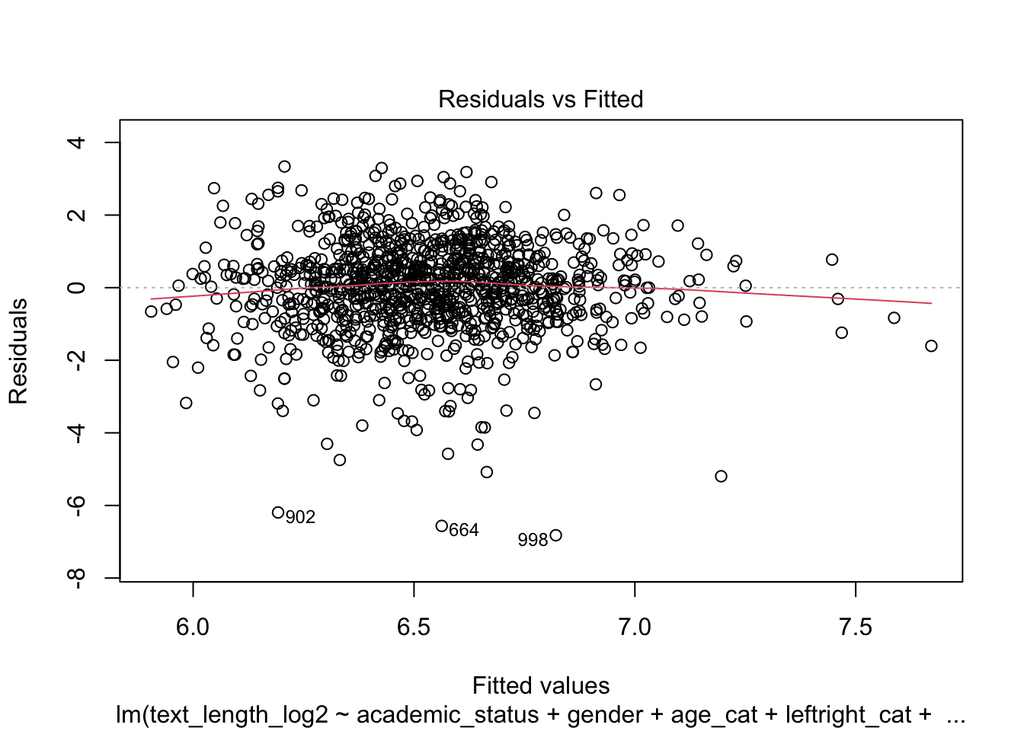

```r
# Plotting residuals vs. fitted values
plot(model_text_length, which = 1)
```

*Q-Q Plots for Normality of Residuals*

Q-Q (quantile-quantile) plot to assess whether the residuals follow a normal distribution

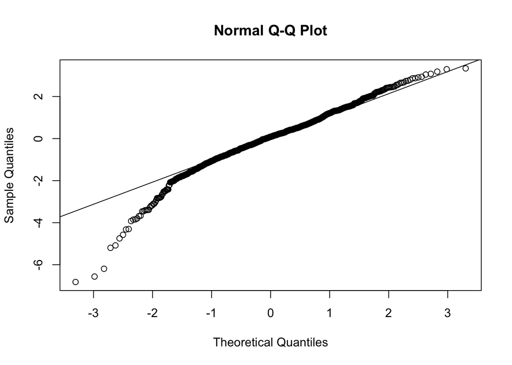

```r
# Q-Q plot
qqnorm(residuals(model_text_length))
qqline(residuals(model_text_length))
```

*Variance Inflation Factor (VIF) for Multicollinearity*

Assesses how much the variance of a coefficient is inflated due to multicollinearity in the model. VIF values above 5 or 10 indicate high multicollinearity that could be problematic.

```r
library(car)
vif(model_text_length)
```

```
##                     GVIF Df GVIF^(1/(2*Df))
## academic_status 1.013538  1        1.006746
## gender          1.046798  2        1.011500
## age_cat         1.063965  3        1.010387
## leftright_cat   1.066119  2        1.016135
## commitment_log2 1.037932  1        1.018790
```

## 2.2 Readability

```r
# Linear regression model with all controls
model_readability <- lm(readability_score ~ academic_status + gender + age_cat + leftright_cat + commitment_log2, data = data)

summary(model_readability)
```

```
##
## Call:
## lm(formula = readability_score ~ academic_status + gender + age_cat +
##     leftright_cat + commitment_log2, data = data)
##
## Residuals:
##     Min      1Q  Median      3Q     Max
## -19.830  -3.151  -0.015   3.145  22.205
##
## Coefficients:
##                                 Estimate Std. Error t value Pr(>|t|)
## (Intercept)                      10.1297     1.0469   9.676  < 2e-16 ***
## academic_statusacademic           0.7584     0.3341   2.270  0.02341 *
## genderFemale                      0.2794     0.3561   0.785  0.43292
## genderOther                       1.7050     1.3518   1.261  0.20747
## age_cat30-49                      0.2058     0.4587   0.449  0.65379
## age_cat50-69                     -0.7549     0.4665  -1.618  0.10591
## age_cat70+                       -2.3082     0.7894  -2.924  0.00353 **
## leftright_catmoderate/center     -1.7635     0.4152  -4.247 2.36e-05 ***
## leftright_catconservative/right  -2.0039     0.4538  -4.416 1.11e-05 ***
## commitment_log2                   0.7808     0.2774   2.815  0.00497 **
## ---
## Signif. codes:  0 '***' 0.001 '**' 0.01 '*' 0.05 '.' 0.1 ' ' 1
##
## Residual standard error: 5.319 on 1039 degrees of freedom
##   (14 observations deleted due to missingness)
## Multiple R-squared:  0.04869,    Adjusted R-squared:  0.04045
## F-statistic: 5.909 on 9 and 1039 DF,  p-value: 4.446e-08
```

```r
stargazer(model_readability, type = "text")
```

```
##
## ===========================================================
##                                     Dependent variable:
##                                 ---------------------------
##                                      readability_score
## -----------------------------------------------------------
## academic_statusacademic                   0.758**
##                                           (0.334)
##
## genderFemale                               0.279
##                                           (0.356)
##
## genderOther                                1.705
##                                           (1.352)
##
## age_cat30-49                               0.206
##                                           (0.459)
##
## age_cat50-69                              -0.755
##                                           (0.467)
##
## age_cat70+                               -2.308***
##                                           (0.789)
##
## leftright_catmoderate/center             -1.763***
##                                           (0.415)
##
## leftright_catconservative/right          -2.004***
##                                           (0.454)
##
## commitment_log2                          0.781***
##                                           (0.277)
##
## Constant                                 10.130***
##                                           (1.047)
##
## -----------------------------------------------------------
## Observations                               1,049
## R2                                         0.049
## Adjusted R2                                0.040
## Residual Std. Error                  5.319 (df = 1039)
## F Statistic                       5.909*** (df = 9; 1039)
## ===========================================================
## Note:                           *p<0.1; **p<0.05; ***p<0.01
```

*Residuals Plot for Homoscedasticity and Linearity*

check if the residuals (differences between observed and predicted values) display constant variance across all levels of the predicted values (homoscedasticity) and if the relationship between the predictors and the outcome is linear.

**Homoscedasticity**: The spread of residuals should be roughly constant across all fitted values.

**Linearity**: The residuals should be randomly dispersed around the horizontal axis, without any systematic shape.

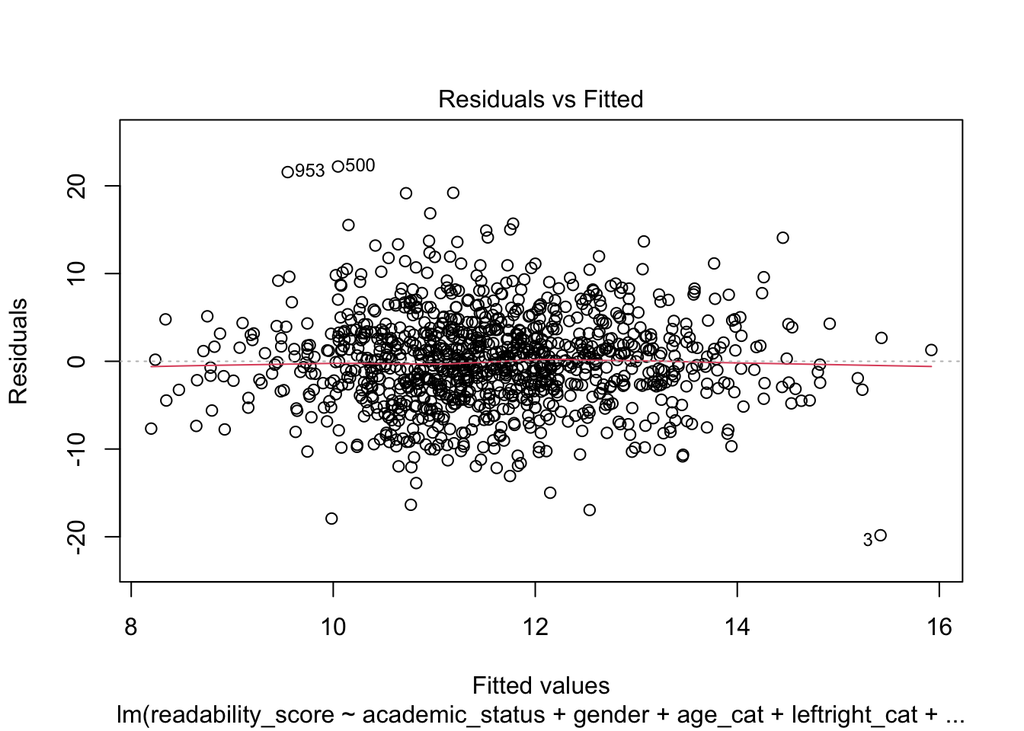

```r
# Plotting residuals vs. fitted values
plot(model_readability, which = 1)
```

*Q-Q Plots for Normality of Residuals*

Q-Q (quantile-quantile) plot to assess whether the residuals follow a normal distribution

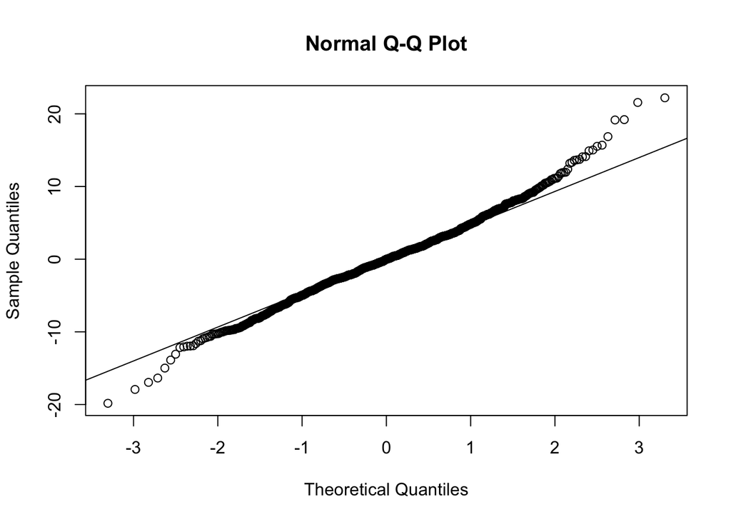

```r
# Q-Q plot
qqnorm(residuals(model_readability))
qqline(residuals(model_readability))
```

*Variance Inflation Factor (VIF) for Multicollinearity*

Assesses how much the variance of a coefficient is inflated due to multicollinearity in the model. VIF values above 5 or 10 indicate high multicollinearity that could be problematic.

```r
library(car)

vif(model_readability)
```

```
##                     GVIF Df GVIF^(1/(2*Df))
## academic_status 1.013538  1        1.006746
## gender          1.046798  2        1.011500
## age_cat         1.063965  3        1.010387
## leftright_cat   1.066119  2        1.016135
## commitment_log2 1.037932  1        1.018790
```

## 2.3 Predictability of Political Orientation

```r
## Linear regression model with all controls
#model_leftright_pred_error <- lm(leftright_pred_error ~ academic_status + gender + #age_cat + leftright_cat + commitment_log2, data = data)
#
#summary(model_leftright_pred_error)
#
#stargazer(model_leftright_pred_error, type = "text")
```

*Residuals Plot for Homoscedasticity and Linearity*

check if the residuals (differences between observed and predicted values) display constant variance across all levels of the predicted values (homoscedasticity) and if the relationship between the predictors and the outcome is linear.

**Homoscedasticity**: The spread of residuals should be roughly constant across all fitted values.

**Linearity**: The residuals should be randomly dispersed around the horizontal axis, without any systematic shape.

[figure not shown]

```r
# Plotting residuals vs. fitted values
plot(model_text_length, which = 1)
```

*Q-Q Plots for Normality of Residuals*

Q-Q (quantile-quantile) plot to assess whether the residuals follow a normal distribution

```r
# Q-Q plot
#qqnorm(residuals(model_text_length))
#qqline(residuals(model_text_length))
```

*Variance Inflation Factor (VIF) for Multicollinearity*

Assesses how much the variance of a coefficient is inflated due to multicollinearity in the model. VIF values above 5 or 10 indicate high multicollinearity that could be problematic.

```r
#library(car)
#
#vif(model_text_length)
```

## 2.4 Model Table

```r
# create Latex table
stargazer(model_text_length, model_readability,
          dep.var.labels = c("Text length (log2)", "Readability"),
          covariate.labels = c("Academic", "Female", "Other", "30-49", "50-69", "70+", "Moderate/Center", "Conservative/Right", "Survey Commitment (log2)")
          )
```

```
##
## % Table created by stargazer v.5.2.3 by Marek Hlavac, Social Policy Institute. E-mail: marek.hlavac at gmail.com
## % Date and time: Fri, May 03, 2024 - 11:49:56
## \begin{table}[!htbp] \centering
##   \caption{}
##   \label{}
## \begin{tabular}{@{\extracolsep{5pt}}lcc}
## \\[-1.8ex]\hline
## \hline \\[-1.8ex]
##  & \multicolumn{2}{c}{\textit{Dependent variable:}} \\
## \cline{2-3}
## \\[-1.8ex] & Text length (log2) & Readability \\
## \\[-1.8ex] & (1) & (2)\\
## \hline \\[-1.8ex]
##  Academic & 0.024 & 0.758$^{**}$ \\
##   & (0.081) & (0.334) \\
##   & & \\
##  Female & $-$0.038 & 0.279 \\
##   & (0.086) & (0.356) \\
##   & & \\
##  Other & 0.524 & 1.705 \\
##   & (0.327) & (1.352) \\
##   & & \\
##  30-49 & $-$0.171 & 0.206 \\
##   & (0.111) & (0.459) \\
##   & & \\
##  50-69 & $-$0.204$^{*}$ & $-$0.755 \\
##   & (0.113) & (0.467) \\
##   & & \\
##  70+ & $-$0.238 & $-$2.308$^{***}$ \\
##   & (0.191) & (0.789) \\
##   & & \\
##  Moderate/Center & $-$0.132 & $-$1.763$^{***}$ \\
##   & (0.100) & (0.415) \\
##   & & \\
##  Conservative/Right & $-$0.334$^{***}$ & $-$2.004$^{***}$ \\
##   & (0.110) & (0.454) \\
##   & & \\
##  Survey Commitment (log2) & 0.297$^{***}$ & 0.781$^{***}$ \\
##   & (0.067) & (0.277) \\
##   & & \\
##  Constant & 5.842$^{***}$ & 10.130$^{***}$ \\
##   & (0.253) & (1.047) \\
##   & & \\
## \hline \\[-1.8ex]
## Observations & 1,049 & 1,049 \\
## R$^{2}$ & 0.034 & 0.049 \\
## Adjusted R$^{2}$ & 0.025 & 0.040 \\
## Residual Std. Error (df = 1039) & 1.285 & 5.319 \\
## F Statistic (df = 9; 1039) & 4.002$^{***}$ & 5.909$^{***}$ \\
## \hline
## \hline \\[-1.8ex]
## \textit{Note:}  & \multicolumn{2}{r}{$^{*}$p$<$0.1; $^{**}$p$<$0.05; $^{***}$p$<$0.01} \\
## \end{tabular}
## \end{table}
```

```r
# create text table
stargazer(model_text_length, model_readability, type = "text",
          dep.var.labels = c("Text length (log2)", "Readability"),
          covariate.labels = c("Academic", "Female", "Other", "30-49", "50-69", "70+", "Moderate/Center", "Conservative/Right", "Survey Commitment (log2)")
          )
```

```
##
## ==============================================================
##                                      Dependent variable:
##                                 ------------------------------
##                                 Text length (log2) Readability
##                                        (1)             (2)
## --------------------------------------------------------------
## Academic                              0.024          0.758**
##                                      (0.081)         (0.334)
##
## Female                                -0.038          0.279
##                                      (0.086)         (0.356)
##
## Other                                 0.524           1.705
##                                      (0.327)         (1.352)
##
## 30-49                                 -0.171          0.206
##                                      (0.111)         (0.459)
##
## 50-69                                -0.204*         -0.755
##                                      (0.113)         (0.467)
##
## 70+                                   -0.238        -2.308***
##                                      (0.191)         (0.789)
##
## Moderate/Center                       -0.132        -1.763***
##                                      (0.100)         (0.415)
##
## Conservative/Right                  -0.334***       -2.004***
##                                      (0.110)         (0.454)
##
## Survey Commitment (log2)             0.297***       0.781***
##                                      (0.067)         (0.277)
##
## Constant                             5.842***       10.130***
##                                      (0.253)         (1.047)
##
## --------------------------------------------------------------
## Observations                          1,049           1,049
## R2                                    0.034           0.049
## Adjusted R2                           0.025           0.040
## Residual Std. Error (df = 1039)       1.285           5.319
## F Statistic (df = 9; 1039)           4.002***       5.909***
## ==============================================================
## Note:                              *p<0.1; **p<0.05; ***p<0.01
```

## 2.5 Cluster (multinomial logistic regression)

```r
library(nnet)

# Fit multinomial logistic regression model
model_cluster <- multinom(cluster ~ academic_status + gender + age_cat + leftright_cat + commitment_log2, data = data)
summary(model_cluster)
```

```
## Call:
## multinom(formula = cluster ~ academic_status + gender + age_cat +
##     leftright_cat + commitment_log2, data = data)
##
## Coefficients:
##                    (Intercept) academic_statusacademic genderFemale genderOther
## Harms-based          0.4799184             -0.52184692    0.1053453  -1.3247553
## Harms-based narrow  -0.5633902             -0.04899024    0.1700686  -0.7237851
## Denying/Nonsense    -0.8620096             -0.42835422   -0.4716991   0.3850275
##                    age_cat30-49 age_cat50-69 age_cat70+
## Harms-based          0.26226936    0.5519915  0.6823168
## Harms-based narrow   0.01599316    0.2524287 -0.2174359
## Denying/Nonsense     0.23581629    0.8207751  0.5277846
##                    leftright_catmoderate/center leftright_catconservative/right
## Harms-based                          0.36844667                       0.4998359
## Harms-based narrow                  -0.01181032                       0.2776365
## Denying/Nonsense                     1.24677484                       1.8664325
##                    commitment_log2
## Harms-based            -0.19103338
## Harms-based narrow     -0.01091135
## Denying/Nonsense       -0.27961073
##
## Std. Errors:
##                    (Intercept) academic_statusacademic genderFemale genderOther
## Harms-based          0.4955555               0.1608996    0.1677188   0.8173518
## Harms-based narrow   0.5709217               0.1910127    0.1937785   0.8145897
## Denying/Nonsense     0.6537314               0.1980995    0.2278644   0.6371653
##                    age_cat30-49 age_cat50-69 age_cat70+
## Harms-based           0.2157699    0.2238160  0.3714009
## Harms-based narrow    0.2454483    0.2531984  0.4809046
## Denying/Nonsense      0.2788837    0.2826319  0.4741445
##                    leftright_catmoderate/center leftright_catconservative/right
## Harms-based                           0.1915966                       0.2191242
## Harms-based narrow                    0.2192198                       0.2490274
## Denying/Nonsense                      0.3039827                       0.3154558
##                    commitment_log2
## Harms-based              0.1325514
## Harms-based narrow       0.1514968
## Denying/Nonsense         0.1679210
##
## Residual Deviance: 2718.805
## AIC: 2778.805
```

```r
# create text table
stargazer(model_cluster, type = "text")
```

```
##
## ===============================================================================
##                                               Dependent variable:
##                                 -----------------------------------------------
##                                 Harms-based Harms-based narrow Denying/Nonsense
##                                     (1)            (2)               (3)
## -------------------------------------------------------------------------------
## academic_statusacademic          -0.522***        -0.049           -0.428**
##                                   (0.161)        (0.191)           (0.198)
##
## genderFemale                       0.105          0.170            -0.472**
##                                   (0.168)        (0.194)           (0.228)
##
## genderOther                       -1.325          -0.724            0.385
##                                   (0.817)        (0.815)           (0.637)
##
## age_cat30-49                       0.262          0.016             0.236
##                                   (0.216)        (0.245)           (0.279)
##
## age_cat50-69                      0.552**         0.252            0.821***
##                                   (0.224)        (0.253)           (0.283)
##
## age_cat70+                        0.682*          -0.217            0.528
##                                   (0.371)        (0.481)           (0.474)
##
## leftright_catmoderate/center      0.368*          -0.012           1.247***
##                                   (0.192)        (0.219)           (0.304)
##
## leftright_catconservative/right   0.500**         0.278            1.866***
##                                   (0.219)        (0.249)           (0.315)
##
## commitment_log2                   -0.191          -0.011           -0.280*
##                                   (0.133)        (0.151)           (0.168)
##
## Constant                           0.480          -0.563            -0.862
##                                   (0.496)        (0.571)           (0.654)
##
## -------------------------------------------------------------------------------
## Akaike Inf. Crit.                2,778.805      2,778.805         2,778.805
## ===============================================================================
## Note:                                               *p<0.1; **p<0.05; ***p<0.01
```

```r
# create Latex table
stargazer(model_cluster,
          covariate.labels = c("Academic", "Female", "Other", "30-49", "50-69", "70+", "Moderate/Center", "Conservative/Right", "Survey Commitment (log2)")
          )
```

```
##
## % Table created by stargazer v.5.2.3 by Marek Hlavac, Social Policy Institute. E-mail: marek.hlavac at gmail.com
## % Date and time: Fri, May 03, 2024 - 11:49:59
## \begin{table}[!htbp] \centering
##   \caption{}
##   \label{}
## \begin{tabular}{@{\extracolsep{5pt}}lccc}
## \\[-1.8ex]\hline
## \hline \\[-1.8ex]
##  & \multicolumn{3}{c}{\textit{Dependent variable:}} \\
## \cline{2-4}
## \\[-1.8ex] & Harms-based & Harms-based narrow & Denying/Nonsense \\
## \\[-1.8ex] & (1) & (2) & (3)\\
## \hline \\[-1.8ex]
##  Academic & $-$0.522$^{***}$ & $-$0.049 & $-$0.428$^{**}$ \\
##   & (0.161) & (0.191) & (0.198) \\
##   & & & \\
##  Female & 0.105 & 0.170 & $-$0.472$^{**}$ \\
##   & (0.168) & (0.194) & (0.228) \\
##   & & & \\
##  Other & $-$1.325 & $-$0.724 & 0.385 \\
##   & (0.817) & (0.815) & (0.637) \\
##   & & & \\
##  30-49 & 0.262 & 0.016 & 0.236 \\
##   & (0.216) & (0.245) & (0.279) \\
##   & & & \\
##  50-69 & 0.552$^{**}$ & 0.252 & 0.821$^{***}$ \\
##   & (0.224) & (0.253) & (0.283) \\
##   & & & \\
##  70+ & 0.682$^{*}$ & $-$0.217 & 0.528 \\
##   & (0.371) & (0.481) & (0.474) \\
##   & & & \\
##  Moderate/Center & 0.368$^{*}$ & $-$0.012 & 1.247$^{***}$ \\
##   & (0.192) & (0.219) & (0.304) \\
##   & & & \\
##  Conservative/Right & 0.500$^{**}$ & 0.278 & 1.866$^{***}$ \\
##   & (0.219) & (0.249) & (0.315) \\
##   & & & \\
##  Survey Commitment (log2) & $-$0.191 & $-$0.011 & $-$0.280$^{*}$ \\
##   & (0.133) & (0.151) & (0.168) \\
##   & & & \\
##  Constant & 0.480 & $-$0.563 & $-$0.862 \\
##   & (0.496) & (0.571) & (0.654) \\
##   & & & \\
## \hline \\[-1.8ex]
## Akaike Inf. Crit. & 2,778.805 & 2,778.805 & 2,778.805 \\
## \hline
## \hline \\[-1.8ex]
## \textit{Note:}  & \multicolumn{3}{r}{$^{*}$p$<$0.1; $^{**}$p$<$0.05; $^{***}$p$<$0.01} \\
## \end{tabular}
## \end{table}
```